# Google Stock Data April 2014 - April 2015

In this section, we cover the uses of the **Lag**, **Difference**, and **Sign** data transformations in the creation of a time series of Google stock from April 2014 to April 2015. The time series will color coded to display overall increase and decrease of stock price by month.

**Lag Function**  
The *lag(x)* function is used to shift the values associated with a time series down a column by one unit, replacing the first entry with ‘NA’. This is useful for finding the day to day (or month to month, year to year, etc.) difference between between a changing value.

**Difference Function**  
The *diff(x1, x2)* function is used to subtract entries of one vector from corresponding entries in another vector of the same length.

In this case, we use *lag(x)* to shift a column containing Google’s stock prices on the last date of each month from April 2014 - April 2015 down an index. We then use the difference function to subtract the lagged column from the original column.

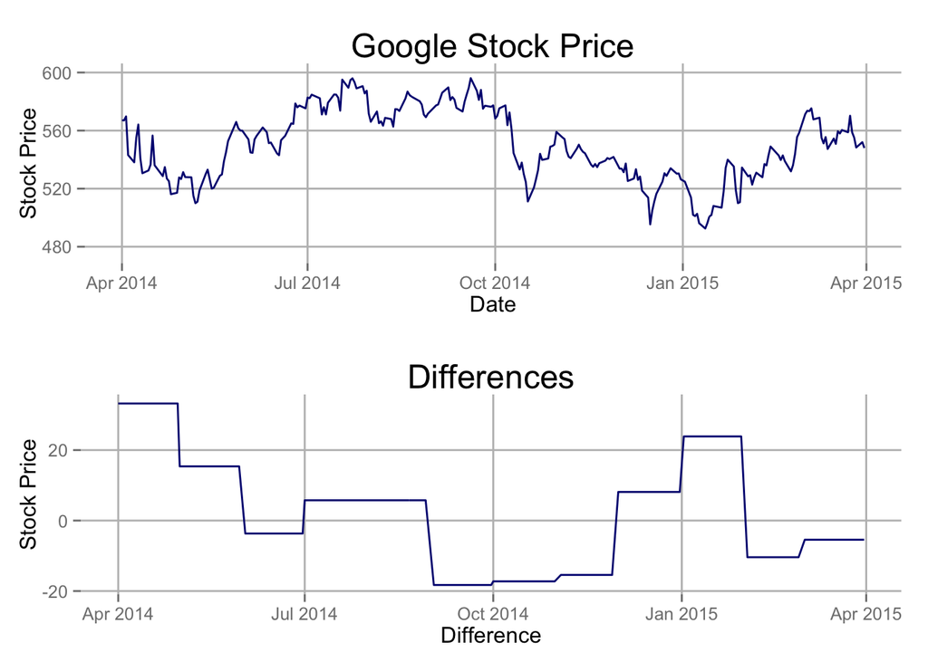

**The Sign Function**  
We use the *sign(x)* to simply determine whether each number in a vector is positive, negative, or 0 by mapping it to 1, -1, or 0 respectively. In this case, we look at the sign of the month to month difference we calculated above in Google stock price data.

We are now capable of plotting the sign of the month to month change of Google stock:

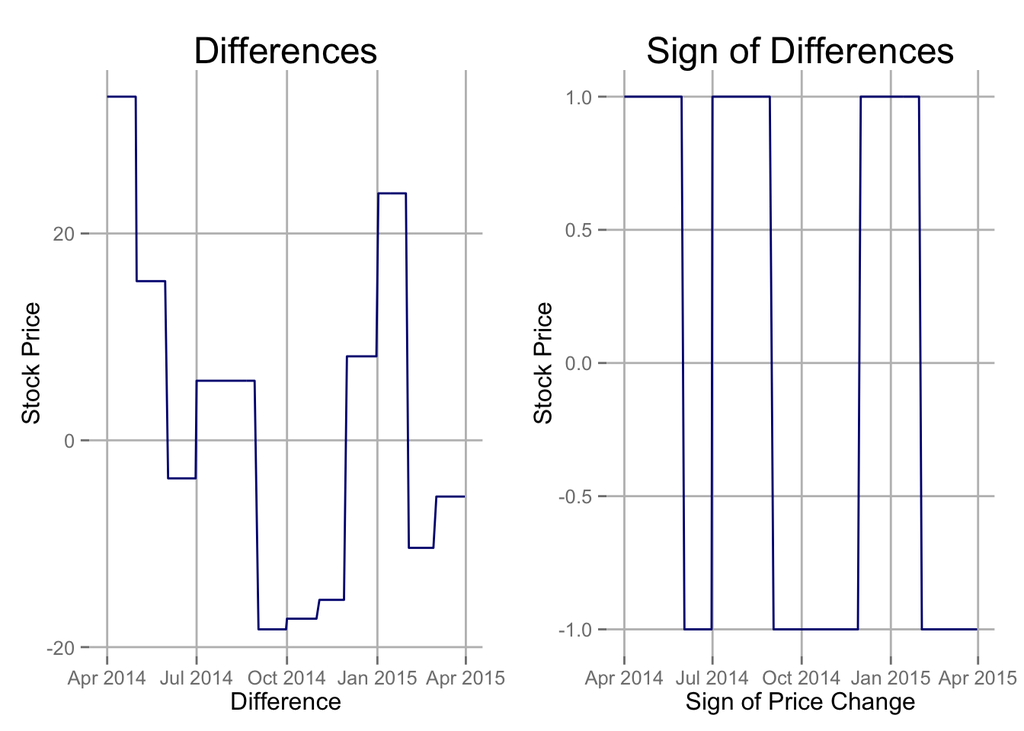

**A final product of our use of the lag, difference, and sign functions:**  
Where the line is green, Google saw an overall increase in price for that month. Similarly, where the stock is red, Google saw an overall decrease for that month. With a visual like this, we can search for trends in the day to day behavior of a stock during times when it sees an overall increase or decrease.

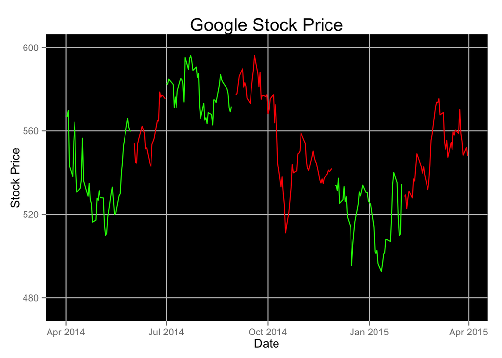